# Workshop Week 5

Author

STAT5003

# 1 Learning Outcomes

**Learning Outcomes**

- Use `hclust`, `kmeans` and `prcomp` to explore data decomposition with hierarchical clustering, (k)-means and PCA.
- Use `Rtsne` for data visualizations.
- Understand how **perplexity** can affect the TSNE results.
- Understand the differences between clustering algorithms and data visualization.

This part of the workshop is based on a chapter in an online book by Rafael Irizarry. You can find it [here](https://rafalab.github.io/dsbook/). There are lots of examples in this book to show you how to use `R` for data science.

# 2 Loading Packages

At the start of your R workshop, load all necessary packages to ensure a smooth session. Here’s an example:

```r
library(dplyr)      # Data manipulation
library(tidyr)      # Tidying data
library(tidyverse)  # Data science packages
library(ggplot2)    # Data visualization
library(here)       # File paths
library(Rtsne)      # t-SNE for dimensionality reduction
library(ggpubr)     # Publication-ready plots
library(Rtsne)      # t-SNE algorithm
library(gridExtra)
```

# 3 Movie ratings data

We will be analysing the [MovieLens dataset](https://grouplens.org/datasets/movielens/latest/) which contains movie ratings of 58,000 movies by 280,000 users. Given its large size, in this workshop, we will focus on the top 40 movies with the most ratings and users who rated at least 20 out of the 40 movies.

**Reading Data**

Download the `movielens_top40.csv` from Canvas and read into R as `movielens`. In this case, the data is structured in the opposite of a typical data layout. whereby the variables of interest are the movies and they appear on the rows and the user response values appear as the columns. This is done somewhat intentionally for the distance calculations coming soon that computes the pairwise distances, where the pairing is done by row.

```r
movielens <- read.csv(here("datasets", "movielens_top40.csv"), header = TRUE)
dim(movielens)
```

```
[1]  40 153
```

```r
range(movielens, na.rm = TRUE)
```

```
[1] 0.5 5.0
```

```r
head(movielens)
```

```
                          user_1 user_6 user_7 user_15 user_17 user_18 user_19
Aladdin (1992)                NA      5    3.0       3      NA     3.5       3
American Beauty (1999)         5     NA    4.0       4     4.0      NA       4
Apollo 13 (1995)              NA      4    4.5      NA     3.5      NA      NA
Back to the Future (1985)      5     NA    5.0       5     4.5     4.0       4
Batman (1989)                  4      3    3.0      NA     4.5      NA       5
Braveheart (1995)              4      5     NA      NA     4.5     4.5      NA
                          user_21 user_28 user_39 user_42 user_45 user_57
Aladdin (1992)                4.0      NA       4      NA     5.0       4
American Beauty (1999)        2.0     4.0       5      NA     5.0       5
Apollo 13 (1995)               NA      NA      NA       5     5.0       3
Back to the Future (1985)     5.0      NA       4       4     3.5       4
Batman (1989)                 3.5     2.5       4       3      NA       4
Braveheart (1995)              NA     3.5      NA       4     5.0       4
                          user_58 user_62 user_63 user_64 user_66 user_68
Aladdin (1992)                  5      NA     4.0     4.0      NA     3.5
American Beauty (1999)         NA      NA     5.0     2.5       5     5.0
Apollo 13 (1995)                4      NA     3.0      NA      NA     3.0
Back to the Future (1985)      NA     4.5     5.0      NA       3     3.0
Batman (1989)                   3      NA     4.0      NA       4     4.0
Braveheart (1995)               5     4.5     2.5     4.0       5     2.5
                          user_72 user_82 user_84 user_86 user_91 user_96
Aladdin (1992)                 NA     2.5      NA       4     3.5      NA
American Beauty (1999)        4.5      NA      NA       4      NA       5
Apollo 13 (1995)              4.0      NA       5      NA     3.5       5
Back to the Future (1985)     4.0     4.0       3      NA     3.5      NA
Batman (1989)                  NA     3.5       3      NA     5.0      NA
Braveheart (1995)             4.5     4.5      NA      NA     4.0       5
                          user_103 user_105 user_109 user_112 user_115 user_117
Aladdin (1992)                  NA       NA        3       NA        4        4
American Beauty (1999)          NA      5.0       NA       NA        1       NA
Apollo 13 (1995)               4.0       NA        3      4.0       NA        4
Back to the Future (1985)       NA       NA       NA      4.0       NA       NA
Batman (1989)                   NA       NA        4       NA        5        3
Braveheart (1995)              4.5      3.5        5      3.5        3        5
                          user_122 user_132 user_135 user_137 user_140 user_141
Aladdin (1992)                  NA      3.5       NA      4.0        3      4.0
American Beauty (1999)          NA      4.5        4       NA        4       NA
Apollo 13 (1995)                NA       NA       NA      3.5        5      3.5
Back to the Future (1985)      5.0      3.5       NA      3.5        3      2.5
```

[output cut: 127 more lines]

```
Braveheart (1995)              5.0      4.0      3.0      5.0       NA        5
                          user_599 user_600 user_602 user_603 user_606 user_607
Aladdin (1992)                 3.0      3.5       NA       NA       NA       NA
American Beauty (1999)         5.0      4.5       NA        5      4.5        3
Apollo 13 (1995)               2.5      2.0        4       NA       NA        5
Back to the Future (1985)      3.5      4.5       NA        2      3.5        3
Batman (1989)                  3.5      2.5        4        2      3.5        3
Braveheart (1995)              3.5      2.0        5        1      3.5        5
                          user_608 user_610
Aladdin (1992)                   3       NA
American Beauty (1999)           5      3.5
Apollo 13 (1995)                 2       NA
Back to the Future (1985)        2      5.0
Batman (1989)                    3      4.5
Braveheart (1995)                4      4.5
```

# 4 Hierarchical clustering

Given the large amount of variables, a natural high-dimensional visualization method is to cluster the movies based on different user ratings. We will look at how to do this in R.

**Basic hclust usage**

Perform hierarchical clustering using the `hclust()` function and use `plot` to graph the resulting dendrogram. Try it with the complete , average and single methods. What can you observe from the hierarchical clustering results processed using different dissimilarity measures?

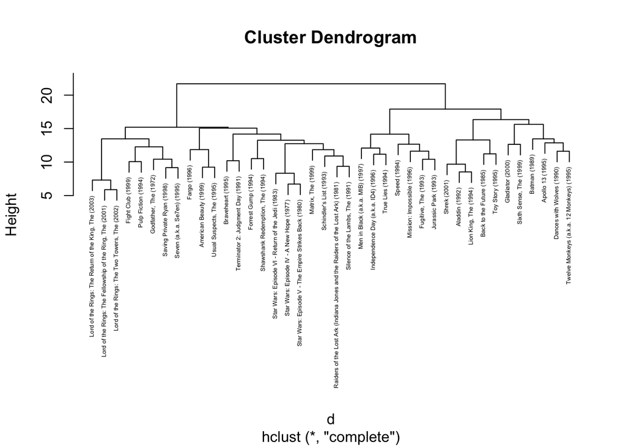

```r
d <- dist(movielens)

h <- hclust(d) ## default is the complete linkage
plot(h, cex = 0.4)
```

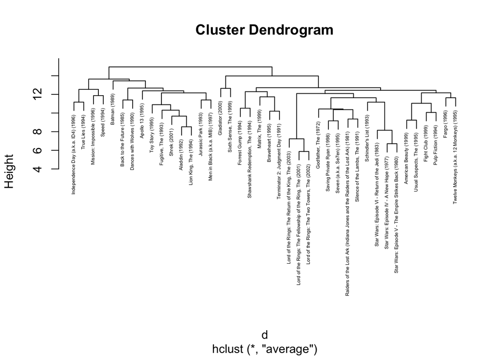

```r
h_avg <- hclust(d, method = "average")

plot(h_avg, cex = 0.4)
```

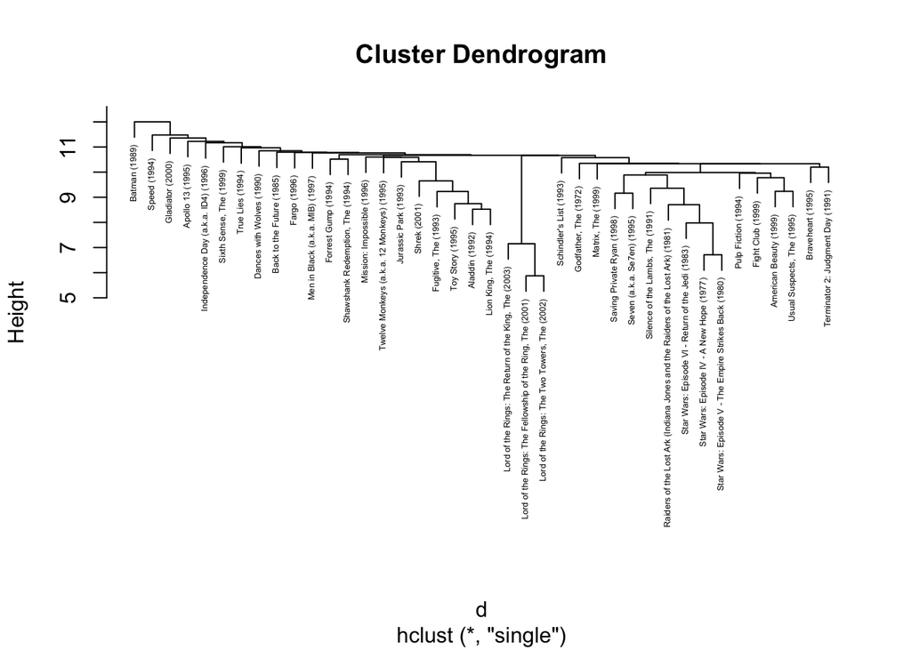

```r
h_single <- hclust(d, method = "single")

plot(h_single, cex = 0.4)
```

Observations on the clustering results:

Complete Linkage: Clusters tend to be more compact and evenly sized, as this method considers the maximum distance between points in different clusters.

Average Linkage: Clusters are balanced between compactness and separation, as it uses the average distance between points in different clusters.

Single Linkage: Clusters can be elongated and less compact, as this method considers the minimum distance between points in different clusters, which can lead to chaining effects.

**Form clusters in hclust**

1. Use the `cutree()` function on the output of `hclust()` using the **complete linkage** to separate the movie titles into **four clusters**.
2. Can you extract the movies in cluster 1?
3. We can also cut the tree by defining a height at which the tree should be cut. Can you find the value of `h` to cut the tree into four clusters?

```r
## use cutree to form four clusters
movie_groups <- cutree(h, k = 4) ## using the default complete linkage
head(movie_groups)
```

```
           Aladdin (1992)    American Beauty (1999)          Apollo 13 (1995)
                        1                         2                         3
Back to the Future (1985)             Batman (1989)         Braveheart (1995)
                        1                         3                         2
```

```r
table(movie_groups)
```

```
movie_groups
 1  2  3  4
 5 22  6  7
```

```r
## split to see the movies in cluster 1
split(names(movie_groups), movie_groups)
```

```
$`1`
[1] "Aladdin (1992)"            "Back to the Future (1985)"
[3] "Lion King, The (1994)"     "Shrek (2001)"
[5] "Toy Story (1995)"

$`2`
 [1] "American Beauty (1999)"
 [2] "Braveheart (1995)"
 [3] "Fargo (1996)"
 [4] "Fight Club (1999)"
 [5] "Forrest Gump (1994)"
 [6] "Godfather, The (1972)"
 [7] "Lord of the Rings: The Fellowship of the Ring, The (2001)"
 [8] "Lord of the Rings: The Return of the King, The (2003)"
 [9] "Lord of the Rings: The Two Towers, The (2002)"
```

[output cut: 30 more lines]

```r
split(names(movie_groups), movie_groups)$`1`
```

```
[1] "Aladdin (1992)"            "Back to the Future (1985)"
[3] "Lion King, The (1994)"     "Shrek (2001)"
[5] "Toy Story (1995)"
```

```r
## try out different heights
table(cutree(h, h = 14)) ## there are 9 clusters if cutting the tree at 14
```

```
1 2 3 4 5 6 7 8 9
5 3 4 2 8 9 4 2 3
```

```r
table(cutree(h, h = 15)) ## there are 7 clusters
```

```
 1  2  3  4  5  6  7
 5  3  4 11  8  7  2
```

```r
table(cutree(h, h = 16)) ## exactly 4 clusters
```

```
 1  2  3  4
 5 22  6  7
```

```r
table(cutree(h, h = 17)) ## only three clusters
```

```
 1  2  3
11 22  7
```

```r
cutree(h, h = 16)
```

```
                                                                Aladdin (1992)
                                                                             1
                                                        American Beauty (1999)
                                                                             2
                                                              Apollo 13 (1995)
                                                                             3
                                                     Back to the Future (1985)
                                                                             1
                                                                 Batman (1989)
                                                                             3
                                                             Braveheart (1995)
                                                                             2
                                                     Dances with Wolves (1990)
                                                                             3
                                                                  Fargo (1996)
                                                                             2
                                                             Fight Club (1999)
                                                                             2
                                                           Forrest Gump (1994)
                                                                             2
                                                          Fugitive, The (1993)
                                                                             4
                                                              Gladiator (2000)
                                                                             3
                                                         Godfather, The (1972)
                                                                             2
                                          Independence Day (a.k.a. ID4) (1996)
                                                                             4
                                                          Jurassic Park (1993)
                                                                             4
                                                         Lion King, The (1994)
                                                                             1
                     Lord of the Rings: The Fellowship of the Ring, The (2001)
                                                                             2
                         Lord of the Rings: The Return of the King, The (2003)
                                                                             2
                                 Lord of the Rings: The Two Towers, The (2002)
                                                                             2
                                                            Matrix, The (1999)
                                                                             2
```

[output cut: 25 more lines]

```
                                                                             2
                         Star Wars: Episode V - The Empire Strikes Back (1980)
                                                                             2
                             Star Wars: Episode VI - Return of the Jedi (1983)
                                                                             2
                                             Terminator 2: Judgment Day (1991)
                                                                             2
                                                              Toy Story (1995)
                                                                             1
                                                              True Lies (1994)
                                                                             4
                                     Twelve Monkeys (a.k.a. 12 Monkeys) (1995)
                                                                             3
                                                    Usual Suspects, The (1995)
                                                                             2
```

[figure not shown]

```r
# Add a horizontal line to the dendrogram to show the cut for 4 clusters
plot(h)
abline(h = 16, col = "red", lty = 2)  # Adjust the height (h) value as needed
```

**Real clustering?**

You may have noticed that not every movie has a rating from every user, resulting in some `NA` values in the dataset. This is expected since no one could have possibly watched every movie. One question you might ask is whether the clustering result is based on the actual rating values (ranging from 1 to 5 stars) or simply on the presence of a rating.

To investigate this, follow these steps:

1. Create a New Dataset `movielens_mat`: Replace all missing ratings (NAs) with 0. Replace all existing ratings (regardless of their value) with 1.
2. Perform Hierarchical Clustering: Use the new dataset to perform hierarchical clustering with the **Manhattan distance**.
3. Find Clusters: Use the `cutree` function to identify 4 clusters.
4. Compare Results: Compare these clusters to the results obtained in the previous question.

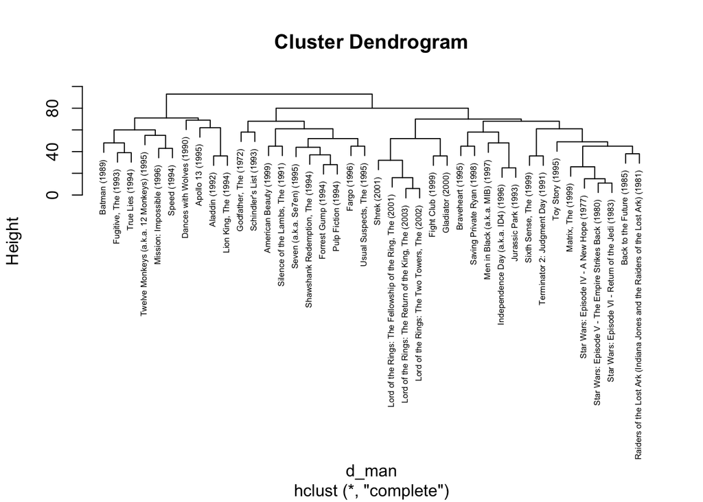

```r
#| echo: true
#| code-fold: true
#| message: false


movielens_mat <- as.matrix(movielens)
movielens_mat[is.na(movielens_mat)] <- 0
movielens_mat[movielens_mat > 0] <- 1

d_man <- dist(movielens_mat, method = "manhattan")
h_man <- hclust(d_man)
plot(h_man, cex = 0.5)
```

```r
movie_groups_man <- cutree(h_man, k = 4)

table(movie_groups_man)
```

```
movie_groups_man
 1  2  3  4
 4 10 20  6
```

```r
table(movie_groups)
```

```
movie_groups
 1  2  3  4
 5 22  6  7
```

```r
## the results show that even if we replace all the rated movies with a rating of 1 and replace all the non-rated movies with a rating of 0, there still appear to be 4 distinct groups (though the group memberships differ with the first approach) and thus it suggests that the clustering is not based on the existence of a rating.

## compare movies in the first cluster
## split to see the movies in cluster 1

split(names(movie_groups), movie_groups)$`1`
```

```
[1] "Aladdin (1992)"            "Back to the Future (1985)"
[3] "Lion King, The (1994)"     "Shrek (2001)"
[5] "Toy Story (1995)"
```

```r
split(names(movie_groups_man), movie_groups_man)$`1`
```

```
[1] "Aladdin (1992)"            "Apollo 13 (1995)"
[3] "Dances with Wolves (1990)" "Lion King, The (1994)"
```

```r
##
```

# 5 K-means

**Basic \(k\)-means usage**

Next, let’s explore the `kmeans` method. Use the original `movielens` data, let’s now make a new dataset named `movielens_mat` replacing all the NAs with 0 but keep the ratings. We are doing this because the `kmeans` function cannot handle missing values. In a later module, we will look at how to handle missing values. Use `kmeans` to cluster the movies into **four clusters**. How many movies are in each cluster?

```r
movielens_mat <- as.matrix(movielens)
movielens_mat[is.na(movielens_mat)] <- 0
kmeans_res <- kmeans(movielens_mat, centers = 4)

names(kmeans_res) ## extract the cluster variable
```

```
[1] "cluster"      "centers"      "totss"        "withinss"     "tot.withinss"
[6] "betweenss"    "size"         "iter"         "ifault"
```

```r
table(kmeans_res$cluster)
```

```
 1  2  3  4
15 10  6  9
```

**Visualization**

1. Use the `prcomp` function to perform PCA on the `movielens_mat` matrix, scaling the data to ensure each feature contributes equally to the analysis.
2. Create a data frame `movie.df` containing the first two principal components (PC1 and PC2) and the cluster labels obtained from k-means clustering.
3. Use `ggplot` to create a scatter plot of the first two principal components, coloring the points by their cluster labels.

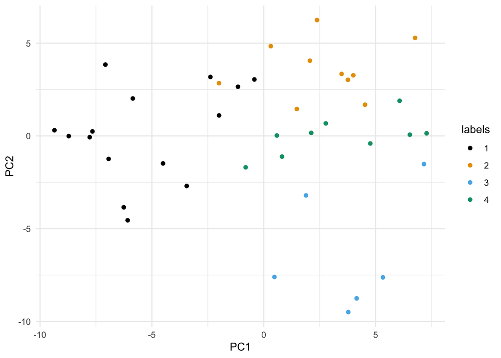

```r
library(ggthemes)

movie_pc <- prcomp(movielens_mat, scale = TRUE)

movie.df <- data.frame(PC1 = movie_pc$x[,1], PC2 = movie_pc$x[,2],
                      labels = factor(kmeans_res$cluster))

ggplot(movie.df, aes(PC1, PC2, colour = labels)) + geom_point() + theme_minimal() +
  scale_colour_colorblind()
```

# 6 Author by word count

The dataset **author_count.csv** shows the counts of common words appearing in documents by four authors, Jane Austen, Jack London, William Shakespeare and John Milton. We like to investigate whether clustering based word characteristics is able to split the four authors apart. Here the first column shows the author, the remaining columns show the counts of each word.

**PCA**

Run the following code to visualize the first two principal components (PCs), with points color-coded by author. Identify which author has the highest score in PC2.

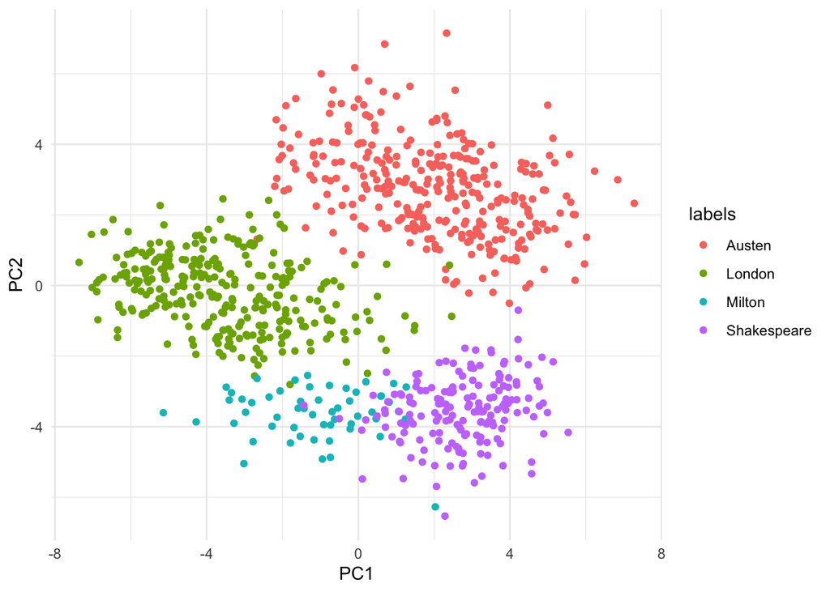

```r
author.dat <- read.csv(here("datasets", "author_count.csv"), header = TRUE)
## remove the first column showing the author & use the remaining numeric values to perform PCA
numeric.dat <- author.dat[,-1]
authors <- factor(author.dat[[1]])

pca.scaled <- prcomp(numeric.dat, scale = TRUE) ## it is important to set scale = TRUE, but why?

author.df <- data.frame(PC1 = pca.scaled$x[,1], PC2 = pca.scaled$x[,2],
                        labels = authors)

pca.plot <- ggplot(author.df, aes(PC1, PC2, col =  labels )) + geom_point() + theme_minimal()
pca.plot
```

It appears that Jane Austen has the highest score in PC2.

**TSNE**

Compute and view the (t)-SNE plots for various perplexity levels for the author data.

1. Set the perplexity level to 5.
2. Read the Help file (`?Rtsne`) to understand what perplexity is doing when running TSNE.
3. Modify the code to set the perplexity level to 10, 30 and 50, and briefly comments on the differences.

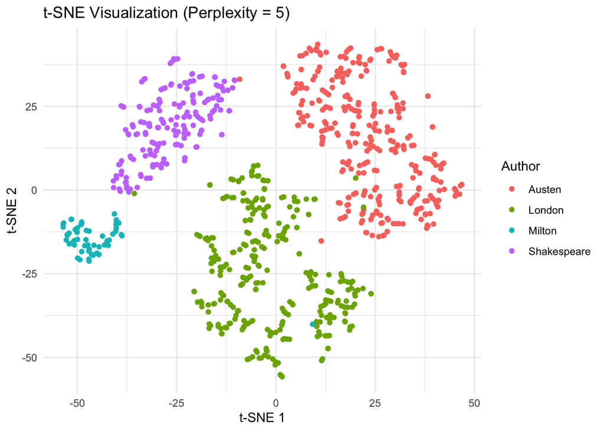

```r
set.seed(5003)

author_tsne <- Rtsne(author.dat[-1], dims = 2, perplexity = 5)$Y


# Create a data frame with the t-SNE results and author information
tsne_data <- data.frame(x = author_tsne[, 1], y = author_tsne[, 2], Author = authors)



# Plot the t-SNE results for setting perplexity to 5
ggplot(tsne_data, aes(x = x, y = y, color = Author)) +
  geom_point() +
  labs(title = "t-SNE Visualization (Perplexity = 5)", x = "t-SNE 1", y = "t-SNE 2") +
  theme_minimal()
```

Use a loop to create 4 t-SNE plots via a loop

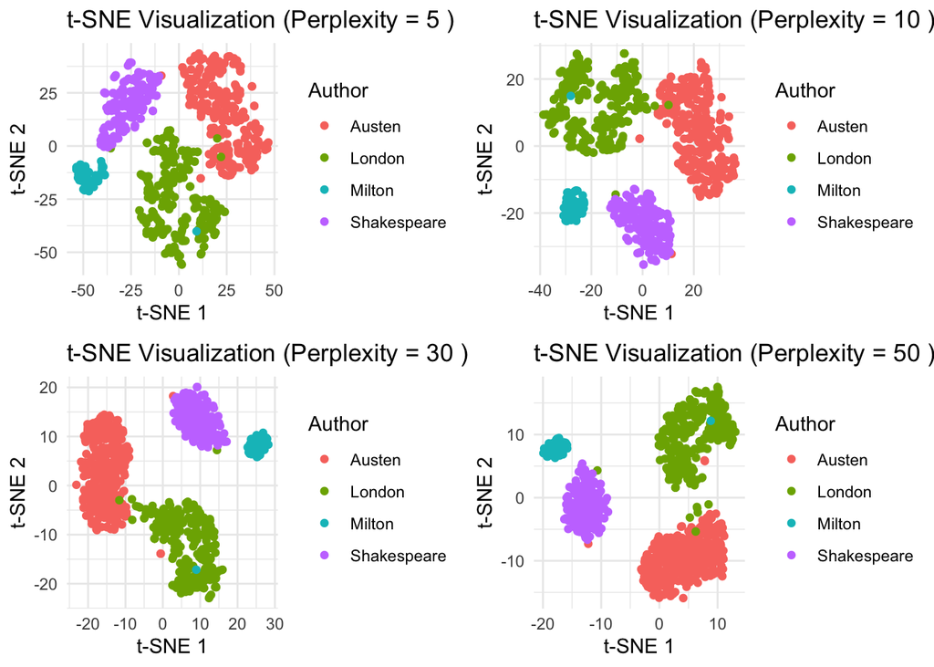

```r
## use a loop to make the plot
perplexities <- c(5, 10, 30, 50)




plots <- list()
for(i in perplexities){
  set.seed(5003)
  author_tsne <- Rtsne(author.dat[,-1], dims = 2, perplexity = i)$Y

  tsne_data <- data.frame(x = author_tsne[, 1], y = author_tsne[, 2], Author = authors)

  plots[[paste0("Perp_", i)]] <- ggplot(tsne_data, aes(x = x, y = y, color = Author)) +
    geom_point() +
    labs(title = paste("t-SNE Visualization (Perplexity =", i, ")"),
         x = "t-SNE 1", y = "t-SNE 2") +
    theme_minimal()
}

# Display all 4 plots
do.call(grid.arrange, c(plots, ncol = 2))
```

Interpretation:

- Low Perplexity: Focuses more on local data structure, capturing fine details. However, it might miss the broader structure and can lead to more scattered points.
- High Perplexity: Emphasizes global data structure, capturing overall patterns. Clusters will tend to shrink into denser structures. This can result in clearer, more defined clusters, but might overlook finer details.